# Get to know me!

Tamar

2026-01-27

# This R Markdown is to get to know Tamar!

## Bio

My name is Tamar! I am a graduate student in the [*Cell and Systems Biology*](https://csb.utoronto.ca/graduate-studies/) program at the University of Toronto. I am researching plant microbe interactions in my graduate degree under the supervision of Profs. David Guttmann and Darrell Desveaux. Before starting my doctorate, I complete a Bachelors of Science at the University of British Columbia studying [*Microbiology and Immunology and Computer Science*](https://mbim.ubc.ca/undergraduate-programs-specializations).

## Bachelors Degree

**Table 1. Record of all undergraduate courses**

```r
# show a table with all my courses
paged_table(courses)
```

| Course.Department | Course.Code | Year | course_type |
| --- | --- | --- | --- |
| ANTH | 227 | 1 | Elective |
| BIOL | 121 | 1 | BSc Requirement |
| CHEM | 121 | 1 | BSc Requirement |
| ENGL | 110 | 1 | BSc Requirement |
| PHYS | 100 | 1 | BSc Requirement |
| BIOL | 112 | 1 | BSc Requirement |
| BIOL | 140 | 1 | Elective |
| CHEM | 123 | 1 | BSc Requirement |
| CPSC | 110 | 1 | Major Requirement |
| MATH | 105 | 1 | BSc Requirement |

[output cut: 30 more lines]

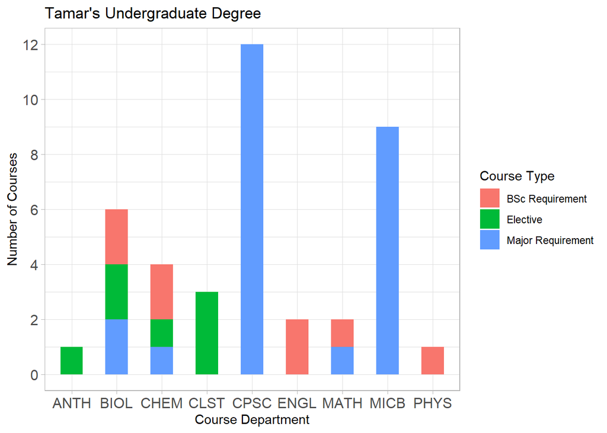

**Figure 1 summary of undergraduate courses** barplot of the number of courses taken throughout the undergraduate degree. Colors represent the catagory of each course as part of the undergraduate course requirements.

```r
## organize the data for plotting
courses_counts <- courses %>%
  group_by(Course.Department, course_type) %>%
  count()

# plot
ggplot(data=courses_counts, aes(x=Course.Department, y=n, fill=course_type)) +
  geom_bar(stat="identity", width=0.5) +
  labs(y="Number of Courses", x="Course Department", fill="Course Type") +
  theme_light() +
  scale_y_continuous(limits = c(0, 12), breaks = seq(0, 12, by = 2))+
  ggtitle("Tamar's Undergraduate Degree")+
  theme(axis.text.y=element_text(size=12),
        axis.text.x=element_text(size=12))
```

## Hobbies

I have many hobbies such as: knitting, swimming, watching movies, reading, cooking. I have outlined how many hours a week I spend on each hobby.

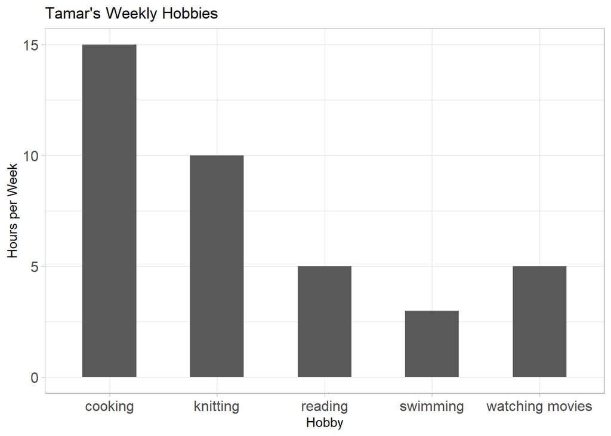

**Figure 2 barplot of the number of hours spent a week on each hobby.**

```r
# plot
ggplot(data=hobbies, aes(x=hobby, y=hours_per_week)) +
  geom_bar(stat="identity", width=0.5) +
  labs(y="Hours per Week", x="Hobby") +
  theme_light() +
  ggtitle("Tamar's Weekly Hobbies")+
  theme(axis.text.y=element_text(size=12),
        axis.text.x=element_text(size=12))
```

Right now my favorite hobby is knitting!

## The sweater I knit!

I finished knitting this sweater 3 months ago. It took me about 80 hours to complete. I got the pattern which is called “Fairy Bouquet” from Ravelry!

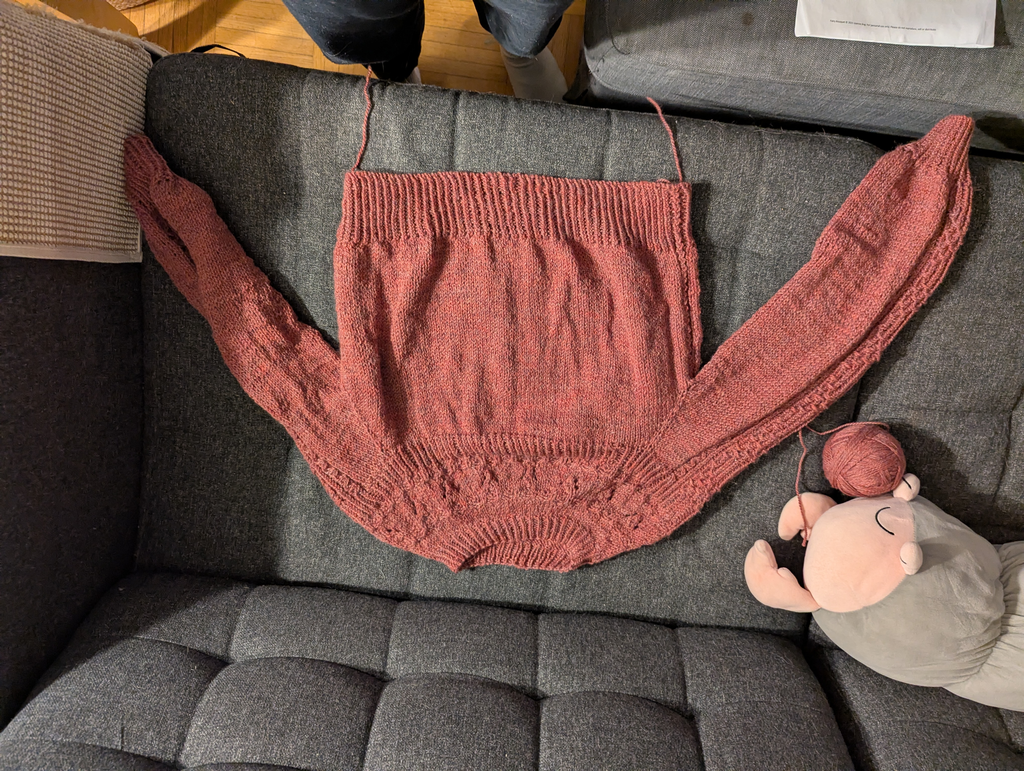

My Sweater

## Questions to answer

1.What is your bachelors degree?

2.Which courses have you taken and in which departments?

3.What are your hobbies?

4.How many hours a week do you spend on each hobby?

5.What is your favorite hobby?

6.Add a custom section of your choosing!

## Citations

Laflamme, Bradley, Marcus M. Dillon, Alexandre Martel, Renan N. D. Almeida, Darrell Desveaux, and David S. Guttman. 2020. “The Pan-Genome Effector-Triggered Immunity Landscape of a Host-Pathogen Interaction.” *Science* 367 (6479): 763–68. https://doi.org/10.1126/science.aax4079.

Wickham, Hadley. 2016. *Ggplot2: Elegant Graphics for Data Analysis*. Springer-Verlag New York. https://ggplot2.tidyverse.org.

Xie, Yihui, Christophe Dervieux, and Emily Riederer. 2020. *R Markdown Cookbook*. Boca Raton, Florida: Chapman; Hall/CRC. https://bookdown.org/yihui/rmarkdown-cookbook.